# Analyse de données de panels : Poligma

Sarah Madeleine & Meriem Michaut

16 février 2018

### Définition du dossier de travail et appel des librairies

```r
setwd("C://Users//adminetu//Desktop//TP_a_rendre//")
library(Matrix)
library(lme4)
library(lmerTest)
library(readxl)
library(tidyverse)
```

### **Traitement des données**

### Import des données

```r
data <- read_csv2(file = "Table_Intersection_BV_IRIS_2012_PRES_All3.csv")
```

On remarque que R signale un certain nombre de doublons dans les variables. On procède à leur retrait.

### Retrait des doublons

```r
data = data[,-c(143,144,227,229,232,234,332)]
#glimpse(data) #observation des données "data"
```

### Retrait des variables inutiles:

Il nous a été imposé de ne travailler qu’avec la catégorie des femmes dans la classe 2. On procède donc au retrait des variables qui ne nous concernent pas.

```r
drops <- c("P12_POP1564", "P12_POP1524", "P12_POP2554", "P12_POP5564", "P12_H1564", "P12_H1524", "P12_H2554", "P12_H5564", "P12_ACT1564", "P12_ACT1524", "P12_ACT2554", "P12_ACT5564", "P12_HACT1564", "P12_HACT1524", "P12_HACT2554", "P12_HACT5564", "P12_ACTOCC1564", "P12_ACTOCC1524", "P12_ACTOCC2554", "P12_ACTOCC5564", "P12_HACTOCC1564", "P12_HACTOCC1524", "P12_HACTOCC2554", "P12_HACTOCC5564", "P12_CHOM1564", "P12_CHOM1524", "P12_CHOM2554", "P12_CHOM5564", "P12_HCHOM1564", "P12_INACT1564", "P12_HINACT1564", "P12_ETUD1564", "P12_HETUD1564", "P12_RETR1564", "P12_HRETR1564", "P12_AINACT1564", "P12_HAINACT1564", "P12_ACTOCC15P", "P12_HACTOCC15P", "P12_SAL15P", "P12_HSAL15P", "P12_NSAL15P", "P12_HNSAL15P", "P12_SAL15P_TP", "P12_HSAL15P_TP", "C12_MENPSEUL", "C12_MENHSEUL", "C12_PMEN_MENPSEUL", "C12_PMEN_MENHSEUL", "P12_NSCOL15P", "P12_NSCOL15P_DIPL0", "P12_NSCOL15P_CEP", "P12_NSCOL15P_BEPC", "P12_NSCOL15P_CAPBEP", "P12_NSCOL15P_BAC", "P12_NSCOL15P_BACP2", "P12_NSCOL15P_SUP", "P12_HNSCOL15P", "P12_HNSCOL15P_DIPL0", "P12_HNSCOL15P_CEP", "P12_HNSCOL15P_BEPC", "P12_HNSCOL15P_CAPBEP", "P12_HNSCOL15P_BAC", "P12_HNSCOL15P_BACP2", "P12_HNSCOL15P_SUP", "P12_POP0014", "P12_POP1529", "P12_POP3044", "P12_POP4559", "P12_POP6074", "P12_POP75P", "P12_POP0019", "P12_POP2064", "P12_POP65P", "P12_POPH", "P12_H0014", "P12_H1529", "P12_H3044", "P12_H4559", "P12_H6074", "P12_H75P", "P12_H0019", "P12_H2064", "P12_H65P", "P12_POPF", "P12_F0014", "P12_F1529", "P12_F3044", "P12_F4559", "P12_F6074", "P12_F75P", "C12_H15P", "C12_H15P_CS1", "C12_H15P_CS2", "C12_H15P_CS3", "C12_H15P_CS4", "C12_H15P_CS5", "C12_H15P_CS6", "C12_H15P_CS7", "C12_H15P_CS8")
donnees <- data[ , !(names(data) %in% drops)]
#glimpse(donnees) #vérification des données "donnees"
```

### Transformation de certaines variables en facteurs

```r
donnees[,1] <- lapply(donnees[,1] , factor) #Bureau_de_vote
donnees[,5] <- lapply(donnees[,5] , factor) #Tour
donnees[,15:17] <- lapply(donnees[,15:17] , factor) #insee_com, nom_com, iris
donnees[,20] <- lapply(donnees[,20] , factor) #typ_iris
#glimpse(donnees) #Verification que les variables ont bien ete modifiees
```

### **Structration du jeu de données:**

### Changement des noms de colonnes commençant pas un “%”

```r
colnames(donnees)[colnames(donnees)=="%_EXPRIMES"] <- "PERC_EXPRIMES"
colnames(donnees)[colnames(donnees)=="%_VOTANTS"] <- "PERC_VOTANTS"
colnames(donnees)[colnames(donnees)=="%_NULS"] <- "PERC_NULS"
colnames(donnees)[colnames(donnees)=="%_ABSTENTION"] <- "PERC_ABSTENTION"
#colnames(donnees) #Verification que les noms de variables ont bien change
```

### Définition de la variable à expliquer

```r
Y=donnees[,6]
Y=unlist(Y, recursive=TRUE, use.names=TRUE) #conversion de Y en vecteur
#is.vector(Y) #verification de la convertion
```

### **Séparation en jeu de données en “test” et “train”**

Séparation à 75% de la taille de l’échantillon

```r
smp_size <- floor(0.75 * nrow(donnees)) #définir la taille de l'échantillon
set.seed(123) #définir l'aléa
train_ind <- sample(seq_len(nrow(donnees)), size = smp_size)
train <- donnees[train_ind, ]
test <- donnees[-train_ind, ]
```

### Séparation de la variable à expliquer

```r
Y_train=train[,6] #récupération de la variable PERC_VOTANTS qui est à la 6ème colonne
Y_test=test[,6] #récupération de la variable PERC_VOTANTS qui est à la 6ème colonne
Y_train=unlist(Y_train, recursive=TRUE, use.names=TRUE) #conversion en vecteur
Y_test=unlist(Y_test, recursive=TRUE, use.names=TRUE) #conversion en vecteur
#is.vector(Y_train) #verification de la convertion
#is.vector(Y_test) #verification de la convertion
```

### **Choix du modèle à effets fixes:**

Pour ce faire, nous avons choisi la méthode d’étude de la corrélation des variables explicatives avec la variable à expliquer.

### Construction du jeu de données avec données numériques exclusivement (sans partition test/train)

```r
drop <- c("Bureau_de_vote","PERC_VOTANTS", "Tour", "insee_com", "nom_com", "iris","nom_iris","typ_iris","code_iris","code_type_iris")
donnees_num = donnees[ , !(names(donnees) %in% drop)]
```

### Test de corrélation de Pearson

Test de corrélation des variables une à une avec Y

```r
correlations = cor(donnees_num, Y, method="pearson", use="complete.obs")
#correlations
```

Le test montre qu’il y a 16 variables qui ont une forte corrélation (valeur absolue la plus proche de 1). Nous prendrons donc ces variables.

### Régression linéaire:

Estimation des paramètres du modèle:

```r
model_16 = lm(Y~P12_NPER_RP_LOCHLMV+P12_ANEM_RP_LOCHLMV+P12_FNSCOL15P_DIPL0+P12_RP_LOCHLMV+DISP_PPMINI12+DISP_PPLOGT12+DISP_PPSOC12+C12_PMEN_CS6+C12_NE24F4P+DEC_TP6012+DISP_TP6012+P12_FAINACT1564+DEC_PCHO12+C12_F15P_CS6+DISP_PPFAM12+P12_ANEM_RP_LOC, data = donnees_num)
#  BIC model_239
BIC162 = BIC(model_16) #26737.18
```

Nous avons effectué une régression linéaire sur les autres variables (celles avec une moins bonne corrélation) et le BIC du modèle obtenu était plus grand que celui-ci. Ce qui confirme le test de corrélation de Pearson. Nous garderons donc ce modèle à 16 variables.

### **Choix du modèle aléatoire:**

Pour ce faire, nous estimerons 3 type de modèles: - Modèle avec effet aléatoire sur l’intercept - Modèle avec effet aléatoire sur la pente - Modèle avec effet aléatoire sur l’intercept et sur la pente en même temps Et nous comparerons ces 3 modèles afin de définir lequel s’adapte au mieux au jeu de données.

### Appel des librairies nécessaires.

```r
library(leaps)
```

### Séparation du jeu de données numériques en “traint” et “test”

```r
smp_size_num <- floor(0.75 * nrow(donnees_num))
set.seed(123)
train_ind_num <- sample(seq_len(nrow(donnees_num)), size = smp_size_num)
train_num <- donnees_num[train_ind_num, ]
test_num <- donnees_num[-train_ind_num, ]
```

### Modèle avec variables à effets fixes et variable à effet aléatoire sur l’intercept*

```r
lmer_model_16 = lmer(Y_train~Tour+P12_NPER_RP_LOCHLMV+P12_ANEM_RP_LOCHLMV+P12_FNSCOL15P_DIPL0+P12_RP_LOCHLMV+DISP_PPMINI12+DISP_PPLOGT12+DISP_PPSOC12+C12_PMEN_CS6+C12_NE24F4P+DEC_TP6012+DISP_TP6012+P12_FAINACT1564+DEC_PCHO12+C12_F15P_CS6+DISP_PPFAM12+P12_ANEM_RP_LOC +(1|Bureau_de_vote), REML = FALSE, data = train)
summary(lmer_model_16)
```

```
## Linear mixed model fit by maximum likelihood t-tests use Satterthwaite
##   approximations to degrees of freedom [lmerMod]
## Formula: Y_train ~ Tour + P12_NPER_RP_LOCHLMV + P12_ANEM_RP_LOCHLMV +
##     P12_FNSCOL15P_DIPL0 + P12_RP_LOCHLMV + DISP_PPMINI12 + DISP_PPLOGT12 +
##     DISP_PPSOC12 + C12_PMEN_CS6 + C12_NE24F4P + DEC_TP6012 +
##     DISP_TP6012 + P12_FAINACT1564 + DEC_PCHO12 + C12_F15P_CS6 +
##     DISP_PPFAM12 + P12_ANEM_RP_LOC + (1 | Bureau_de_vote)
##    Data: train
##
##      AIC      BIC   logLik deviance df.resid
##  17363.5  17486.7  -8661.7  17323.5     3490
##
## Scaled residuals:
##     Min      1Q  Median      3Q     Max
## -5.3176 -0.4578  0.0101  0.5490  5.2651
##
## Random effects:
##  Groups         Name        Variance Std.Dev.
##  Bureau_de_vote (Intercept) 22.079   4.699
##  Residual                    5.627   2.372
## Number of obs: 3510, groups:  Bureau_de_vote, 412
##
## Fixed effects:
##                       Estimate Std. Error         df t value Pr(>|t|)
## (Intercept)          7.869e+01  2.453e-01  4.300e+02 320.821  < 2e-16 ***
## Tour2                1.570e+00  8.711e-02  3.142e+03  18.027  < 2e-16 ***
## P12_NPER_RP_LOCHLMV -3.113e-03  2.245e-03  3.174e+03  -1.387 0.165546
## P12_ANEM_RP_LOCHLMV -5.724e-04  2.216e-04  3.153e+03  -2.582 0.009856 **
## P12_FNSCOL15P_DIPL0 -2.506e-02  5.419e-03  3.155e+03  -4.625 3.91e-06 ***
## P12_RP_LOCHLMV       1.364e-02  5.700e-03  3.183e+03   2.394 0.016734 *
## DISP_PPMINI12        4.307e+00  2.676e+00  3.125e+03   1.609 0.107702
## DISP_PPLOGT12       -1.167e+00  2.687e+00  3.121e+03  -0.434 0.664166
## DISP_PPSOC12        -2.486e+00  2.606e+00  3.120e+03  -0.954 0.340136
## C12_PMEN_CS6        -2.743e-03  2.300e-03  3.186e+03  -1.192 0.233245
## C12_NE24F4P          6.715e-02  2.278e-02  3.154e+03   2.947 0.003231 **
## DEC_TP6012           3.141e-01  1.311e-01  3.174e+03   2.396 0.016630 *
## DISP_TP6012         -5.872e-01  1.905e-01  3.174e+03  -3.083 0.002069 **
## P12_FAINACT1564      1.781e-02  5.688e-03  3.120e+03   3.131 0.001757 **
## DEC_PCHO12           8.351e-01  2.197e-01  3.120e+03   3.800 0.000147 ***
## C12_F15P_CS6        -1.500e-02  1.606e-02  3.154e+03  -0.934 0.350248
## DISP_PPFAM12         4.236e+00  2.611e+00  3.119e+03   1.623 0.104761
## P12_ANEM_RP_LOC      9.514e-05  8.399e-05  3.127e+03   1.133 0.257421
## ---
## Signif. codes:  0 '***' 0.001 '**' 0.01 '*' 0.05 '.' 0.1 ' ' 1
## fit warnings:
## Some predictor variables are on very different scales: consider rescaling
```

On note que le BIC de ce modèle vaut: **17486.735**

### Validation croisée pour le choix des variables:

Afin de définir quelles variables nous allons conserver dans ce modèle, nous effectuons une backward cross-validation (validation croisée dégressive)

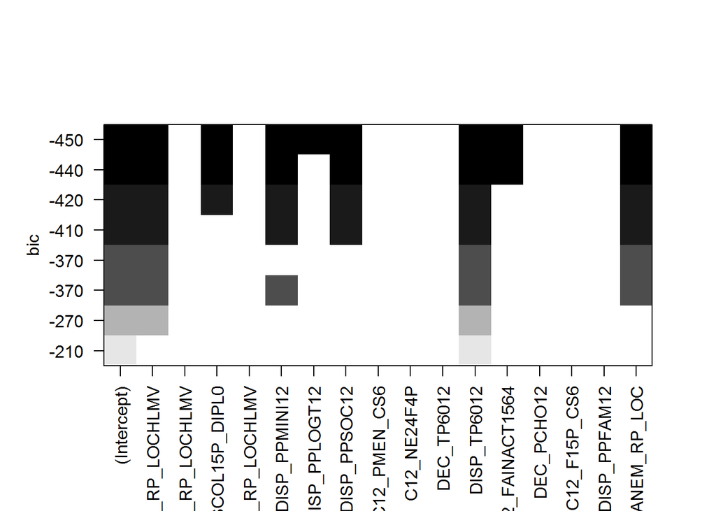

```r
regsub_model_16 = regsubsets(Y_train~P12_NPER_RP_LOCHLMV+P12_ANEM_RP_LOCHLMV+P12_FNSCOL15P_DIPL0+P12_RP_LOCHLMV+DISP_PPMINI12+DISP_PPLOGT12+DISP_PPSOC12+C12_PMEN_CS6+C12_NE24F4P+DEC_TP6012+DISP_TP6012+P12_FAINACT1564+DEC_PCHO12+C12_F15P_CS6+DISP_PPFAM12+P12_ANEM_RP_LOC, method = "backward", data = train_num)
#summary(regsub_model_16)
plot(regsub_model_16, scale="bic")
```

Le graphe du BIC de la cross-validation nous propose de conserver les 9 variables suivantes: **“Intercept”, “P12_NPER_RP_LOCHLMV”, “P12_FNSCOL15P_DIPL0”, “DISP_PPMINI12”, “DISP_PPLOGT12”, “DISP_PPSOC12”, “DISP_TP6012”, “P12_FAINACT1564”,“P12_ANEM_RP_LOC”**

### Estimation des paramètres du modèle avec la méthode ML:

Estimation des paramètres du regsub_model_16 avec facteur à effet fixe *“Tour”* et facteur à effet aléatoire *“Bureau de vote”*

```r
lmer_regsub_model_16 = lmer(Y_train~Tour+P12_NPER_RP_LOCHLMV+P12_FNSCOL15P_DIPL0+DISP_PPMINI12
                            +DISP_PPLOGT12+DISP_PPSOC12+DISP_TP6012+P12_FAINACT1564
                            +P12_ANEM_RP_LOC+(1|Bureau_de_vote), REML = FALSE, data = train)
```

### Estimation avec la méthode REML:

Estimation finale des paramètres du *model_16* avec REML avec facteur à effet fixe *“Tour”* et facteur à effet aléatoire *“Bureau de vote”*

```r
lmer_model_16_REML = lmer(Y_test~Tour+P12_NPER_RP_LOCHLMV+P12_ANEM_RP_LOCHLMV+P12_FNSCOL15P_DIPL0+P12_RP_LOCHLMV+DISP_PPMINI12+DISP_PPLOGT12+DISP_PPSOC12+C12_PMEN_CS6+C12_NE24F4P+DEC_TP6012+DISP_TP6012+P12_FAINACT1564+DEC_PCHO12+C12_F15P_CS6+DISP_PPFAM12+P12_ANEM_RP_LOC+(1|Bureau_de_vote), data = test)
#Prédiction du Y avec lmer_model239_REML
predict_Y_model_16 = predict(lmer_model_16_REML, re.form = NA, data = test)
#RMSE lmer_model_16_REML
rmse_model_16 <- sqrt(mean((Y_test - predict_Y_model_16)^2,na.rm=TRUE))
rmse_model_16
```

### Validation croisée avec la méthode dégressive:

Estimation des paramètres du modèle *regsub_model_16_REML* avec REML avec facteur à effet fixe “Tour” et facteur à effet aléatoire “Bureau de vote”

```r
lmer_regsub_model_16_REML = lmer(Y_test~Tour+P12_NPER_RP_LOCHLMV+P12_FNSCOL15P_DIPL0+DISP_PPMINI12+DISP_PPLOGT12+DISP_PPSOC12+DISP_TP6012+P12_FAINACT1564+P12_ANEM_RP_LOC + (1|Bureau_de_vote), data = test)

#Prédiction du Y avec lmer_regsub_model_16_REML
predict_Y_regsub_model_16 = predict(lmer_regsub_model_16_REML, re.form = NA, data = test)

#RMSE lmer_regsub_model_16_REML
rmse_regsub_model_16 <- sqrt(mean((Y_test - predict_Y_regsub_model_16)^2,na.rm=TRUE))
rmse_regsub_model_16
```

On garde le modele avec le plus petit RMSE soit le **lmer_regsub_model_16_REML** qui a comme variables explicatives:

*Tour, P12_NPER_RP_LOCHLMV, P12_FNSCOL15P_DIPL0, DISP_PPMINI12, DISP_PPLOGT12, DISP_PPSOC12, DISP_TP6012, P12_FAINACT1564, P12_ANEM_RP_LOC*

et comme facteur à effet aléatoire: *Bureau_de_vote*

On note bien que le RMSE pour le meilleur modèle sur l’intercept est : **3.850602**

### Modèle avec variables à effets fixes et variable à effet aleatoire sur la pente*

#### Choix du modèle

Estimation des paramètres du *lmer_regsub_model_16_REML* avec ML avec facteur à effet fixe “Tour” et facteur à effet aléatoire “Bureau de vote”

Pour ce faire, on teste chacune des 9 variables dans la partie aléatoire

Variable 1: **P12_ANEM_RP_LOC**

```r
lmer_regsub_P12_ANEM_RP_LOC_P = lmer(Y_test~Tour+P12_NPER_RP_LOCHLMV+P12_FNSCOL15P_DIPL0+DISP_PPMINI12+DISP_PPLOGT12+DISP_PPSOC12+DISP_TP6012+P12_FAINACT1564+P12_ANEM_RP_LOC+(P12_ANEM_RP_LOC-1|Bureau_de_vote), REML = FALSE, data = test)
# BIC 13409.463
```

Variable 2: **P12_FAINACT1564**

```r
lmer_regsub_P12_FAINACT1564_P = lmer(Y_test~Tour+P12_NPER_RP_LOCHLMV+P12_FNSCOL15P_DIPL0+DISP_PPMINI12+DISP_PPLOGT12+DISP_PPSOC12+DISP_TP6012+P12_FAINACT1564+P12_ANEM_RP_LOC+(P12_FAINACT1564-1|Bureau_de_vote), REML = FALSE, data = test)
# BIC 13385.130
```

Variable 3: **DISP_TP6012**

```r
lmer_regsub_DISP_TP6012_P = lmer(Y_test~Tour+P12_NPER_RP_LOCHLMV+P12_FNSCOL15P_DIPL0+DISP_PPMINI12+DISP_PPLOGT12+DISP_PPSOC12+DISP_TP6012+P12_FAINACT1564+P12_ANEM_RP_LOC+(DISP_TP6012-1|Bureau_de_vote), REML = FALSE, data = test)
# BIC 13409.470
```

Variable 4: **DISP_PPSOC12**

```r
lmer_regsub_DISP_PPSOC12_P = lmer(Y_test~Tour+P12_NPER_RP_LOCHLMV+P12_FNSCOL15P_DIPL0+DISP_PPMINI12+DISP_PPLOGT12+DISP_PPSOC12+DISP_TP6012+P12_FAINACT1564+P12_ANEM_RP_LOC+(DISP_PPSOC12-1|Bureau_de_vote), REML = FALSE, data = test)
# BIC 13361.106
```

Variable 5: **P12_NPER_RP_LOCHLMV**

```r
lmer_regsubset_P12_NPER_RP_LOCHLMV_P = lmer(Y_test~Tour+P12_NPER_RP_LOCHLMV+P12_FNSCOL15P_DIPL0+DISP_PPMINI12+DISP_PPLOGT12+DISP_PPSOC12+DISP_TP6012+P12_FAINACT1564+P12_ANEM_RP_LOC+(P12_NPER_RP_LOCHLMV-1|Bureau_de_vote), data = test, REML = FALSE)
#BIC = 13377.655
```

Variable 6: **P12_FNSCOL15P_DIPL0**

```r
lmer_regsubset_P12_FNSCOL15P_DIPL0_P = lmer(Y_test~Tour+P12_NPER_RP_LOCHLMV+P12_FNSCOL15P_DIPL0+DISP_PPMINI12+DISP_PPLOGT12+DISP_PPSOC12+DISP_TP6012+P12_FAINACT1564+P12_ANEM_RP_LOC+(P12_FNSCOL15P_DIPL0-1|Bureau_de_vote), data = test, REML = FALSE)
#BIC = 13383.460
```

Variable 7: **DISP_PPMINI12**

```r
lmer_regsubset_DISP_PPMINI12_P = lmer(Y_test~Tour+P12_NPER_RP_LOCHLMV+P12_FNSCOL15P_DIPL0+DISP_PPMINI12+DISP_PPLOGT12+DISP_PPSOC12+DISP_TP6012+P12_FAINACT1564+P12_ANEM_RP_LOC+(DISP_PPMINI12-1|Bureau_de_vote), data = test, REML = FALSE)
#BIC = 13357.096
```

Variable 8: **DISP_PPLOGT12**

```r
lmer_regsubset_DISP_PPLOGT12_P = lmer(Y_test~Tour+P12_NPER_RP_LOCHLMV+P12_FNSCOL15P_DIPL0+DISP_PPMINI12+DISP_PPLOGT12+DISP_PPSOC12+DISP_TP6012+P12_FAINACT1564+P12_ANEM_RP_LOC+(DISP_PPLOGT12-1|Bureau_de_vote), data = test, REML = FALSE)
#BIC = 13359.329
```

Variable 9: **DISP_PPSOC12**

```r
lmer_regsubset_DISP_PPSOC12_P = lmer(Y_test~Tour+P12_NPER_RP_LOCHLMV+P12_FNSCOL15P_DIPL0+DISP_PPMINI12+DISP_PPLOGT12+DISP_PPSOC12+DISP_TP6012+P12_FAINACT1564+P12_ANEM_RP_LOC+(DISP_PPSOC12-1|Bureau_de_vote), data = test, REML = FALSE)
#BIC = 13361.106
```

On remarque que le modèle avec la variable *DISP_PPMINI12* a le plus petit BIC = **13357.096** C’est donc sur celui-ci que l’on va effectuer une prédiction.

#### Prédictions:

Nouveau calcul du modèle mais avec la méthode REML cette fois-ci et non pas ML

```r
lmer_regsubset_DISP_PPMINI12_P_REML = lmer(Y_test~Tour+P12_NPER_RP_LOCHLMV+P12_FNSCOL15P_DIPL0+DISP_PPMINI12+DISP_PPLOGT12+DISP_PPSOC12+DISP_TP6012+P12_FAINACT1564+P12_ANEM_RP_LOC+(DISP_PPMINI12-1|Bureau_de_vote), data = test)
#Prediction du Y avec lmer_regsubset_DISP_PPSOC12_REML
predict_DISP_PPSOC12_P = predict(lmer_regsubset_DISP_PPMINI12_P_REML, data = test)
#RMSE lmer_regsubset_DISP_PPSOC12_REML
rmse_DISP_PPSOC12_P <- sqrt(mean((Y_test - predict_DISP_PPSOC12_P)^2,na.rm=TRUE))
rmse_DISP_PPSOC12_P
```

On garde le modele avec le plus petit RMSE soit le **lmer_regsubset_DISP_PPMINI12_P_REML** qui a comme variables explicatives: *Tour, P12_NPER_RP_LOCHLMV, P12_FNSCOL15P_DIPL0, DISP_PPMINI12, DISP_PPLOGT12, DISP_PPSOC12, DISP_TP6012, P12_FAINACT1564, P12_ANEM_RP_LOC* et comme facteur à effet aléatoir: *Bureau_de_vote* sur la pente de la variable *DISP_PPMINI12*

On note bien que le RMSE pour le meilleur modèle sur la pente est : **3.465237**

### Modèle avec variables à effets fixes et variable à effet aleatoire sur la pente et l’intercept*

#### Choix du modèle

Estimation des paramètres du modèle **lmer_regsub_model_16_REML** avec facteur à effet fixe **“Tour”** et facteur effet aléatoir **“Bureau de vote”`** avec la méthode ML.

Comme pour le modèle avec facteur à effet aléatoire sur la pente, on procède au choix du modèle en testant toutes les variables tour à tour dans la partie aléatoire sur la pente.

Variable 1: **P12_ANEM_RP_LOC**

```r
lmer_regsub_P12_ANEM_RP_LOC = lmer(Y_test~Tour+P12_NPER_RP_LOCHLMV+P12_FNSCOL15P_DIPL0+DISP_PPMINI12+DISP_PPLOGT12+DISP_PPSOC12+DISP_TP6012+P12_FAINACT1564+P12_ANEM_RP_LOC+(P12_ANEM_RP_LOC|Bureau_de_vote), REML = FALSE, data = test)
# BIC 12758.334
```

Variable 2: **P12_FAINACT1564**

```r
lmer_regsub_P12_FAINACT1564 = lmer(Y_test~Tour+P12_NPER_RP_LOCHLMV+P12_FNSCOL15P_DIPL0+DISP_PPMINI12+DISP_PPLOGT12+DISP_PPSOC12+DISP_TP6012+P12_FAINACT1564+P12_ANEM_RP_LOC+(P12_FAINACT1564|Bureau_de_vote), REML = FALSE, data = test)
# BIC 12579.993
```

Variable 3: **DISP_TP6012**

```r
lmer_regsub_DISP_TP6012 = lmer(Y_test~Tour+P12_NPER_RP_LOCHLMV+P12_FNSCOL15P_DIPL0+DISP_PPMINI12+DISP_PPLOGT12+DISP_PPSOC12+DISP_TP6012+P12_FAINACT1564+P12_ANEM_RP_LOC+(DISP_TP6012|Bureau_de_vote), REML = FALSE, data = test)
# BIC 12567.799
```

Variable 4: **DISP_PPSOC12**

```r
lmer_regsub_DISP_PPSOC12 = lmer(Y_test~Tour+P12_NPER_RP_LOCHLMV+P12_FNSCOL15P_DIPL0+DISP_PPMINI12+DISP_PPLOGT12+DISP_PPSOC12+DISP_TP6012+P12_FAINACT1564+P12_ANEM_RP_LOC+(DISP_PPSOC12|Bureau_de_vote), REML = FALSE, data = test)
# BIC 12567.82
```

Variable 5: **P12_NPER_RP_LOCHLMV**

```r
lmer_regsubset_P12_NPER_RP_LOCHLMV = lmer(Y_test~Tour+P12_NPER_RP_LOCHLMV+P12_FNSCOL15P_DIPL0+DISP_PPMINI12+DISP_PPLOGT12+DISP_PPSOC12+DISP_TP6012+P12_FAINACT1564+P12_ANEM_RP_LOC+(P12_NPER_RP_LOCHLMV|Bureau_de_vote), data = test, REML = FALSE)
#BIC = 12585.759
```

Variable 6: **P12_FNSCOL15P_DIPL0**

```r
lmer_regsubset_P12_FNSCOL15P_DIPL0 = lmer(Y_test~Tour+P12_NPER_RP_LOCHLMV+P12_FNSCOL15P_DIPL0+DISP_PPMINI12+DISP_PPLOGT12+DISP_PPSOC12+DISP_TP6012+P12_FAINACT1564+P12_ANEM_RP_LOC+(P12_FNSCOL15P_DIPL0|Bureau_de_vote), data = test, REML = FALSE)
#BIC = 12578.870
```

Variable 7: **DISP_PPMINI12**

```r
lmer_regsubset_DISP_PPMINI12 = lmer(Y_test~Tour+P12_NPER_RP_LOCHLMV+P12_FNSCOL15P_DIPL0+DISP_PPMINI12+DISP_PPLOGT12+DISP_PPSOC12+DISP_TP6012+P12_FAINACT1564+P12_ANEM_RP_LOC+(DISP_PPMINI12|Bureau_de_vote), data = test, REML = FALSE)
#BIC = 12572.028
```

Variable 8: **DISP_PPLOGT12**

```r
lmer_regsubset_DISP_PPLOGT12 = lmer(Y_test~Tour+P12_NPER_RP_LOCHLMV+P12_FNSCOL15P_DIPL0+DISP_PPMINI12+DISP_PPLOGT12+DISP_PPSOC12+DISP_TP6012+P12_FAINACT1564+P12_ANEM_RP_LOC+(DISP_PPLOGT12|Bureau_de_vote), data = test, REML = FALSE)
#BIC = 12567.219
```

Variable 9: **DISP_PPSOC12**

```r
lmer_regsubset_DISP_PPSOC12 = lmer(Y_test~Tour+P12_NPER_RP_LOCHLMV+P12_FNSCOL15P_DIPL0+DISP_PPMINI12+DISP_PPLOGT12+DISP_PPSOC12+DISP_TP6012+P12_FAINACT1564+P12_ANEM_RP_LOC+(DISP_PPSOC12|Bureau_de_vote), data = test, REML = FALSE)
#BIC = 12567.82
```

On remarque que le BIC du modèle avec la variable *DISP_PPLOGT12* est le plus petit des 9 : **12567.219**, c’est donc ce modèle que nous conserverons et sur lequel nous ferons les prédictions.

Nouveau calcul du modèle mais avec la méthode REML cette fois-ci et non pas ML

```r
#Estimation des paramètres
lmer_regsubset_DISP_PPLOGT12_REML = lmer(Y_test~Tour+P12_NPER_RP_LOCHLMV+P12_FNSCOL15P_DIPL0+DISP_PPMINI12+DISP_PPLOGT12+DISP_PPSOC12+DISP_TP6012+P12_FAINACT1564+P12_ANEM_RP_LOC+(DISP_PPLOGT12|Bureau_de_vote), data = test)
#Prédiction avec lmer_regsubset_DISP_PPLOGT12
predict_Y_DISP_PPLOGT12 = predict(lmer_regsubset_DISP_PPLOGT12_REML, re.form = NA, data = test)
#RMSE lmer_regsubset_DISP_PPLOGT12
rmse_DISP_PPLOGT12 <- sqrt(mean((Y_test - predict_Y_DISP_PPLOGT12)^2,na.rm=TRUE))
rmse_DISP_PPLOGT12
#3.816147
```

#### Prédictions:

```r
#Estimation des paramètres
lmer_regsub_DISP_PPSOC12_REML = lmer(Y_test~Tour+P12_NPER_RP_LOCHLMV+P12_FNSCOL15P_DIPL0+DISP_PPMINI12+DISP_PPLOGT12+DISP_PPSOC12+DISP_TP6012+P12_FAINACT1564+P12_ANEM_RP_LOC+(DISP_PPSOC12|Bureau_de_vote), data = test)
#Prédiction du Y avec lmer_regsub_DISP_TP6012
predict_Y_DISP_PPSOC12 = predict(lmer_regsub_DISP_PPSOC12_REML, re.form = NA, data = test)
#RMSE lmer_model239_REML
rmse_DISP_PPSOC12 <- sqrt(mean((Y_test - predict_Y_DISP_PPSOC12)^2,na.rm=TRUE))
rmse_DISP_PPSOC12
```

Prédiction avec lmer_regsubset_DISP_PPLOGT12

```r
#Estimation des paramètres
lmer_regsubset_DISP_PPLOGT12_REML = lmer(Y_test~Tour+P12_NPER_RP_LOCHLMV+P12_FNSCOL15P_DIPL0+DISP_PPMINI12+DISP_PPLOGT12+DISP_PPSOC12+DISP_TP6012+P12_FAINACT1564+P12_ANEM_RP_LOC+(DISP_PPLOGT12|Bureau_de_vote), data = test)
#Prédiction du Y avec lmer_regsubset_DISP_PPLOGT12_REML
predict_DISP_PPLOGT12 = predict(lmer_regsubset_DISP_PPLOGT12_REML, re.form = NA, data = test)
#RMSE lmer_regsubset_DISP_PPLOGT12
rmse_DISP_PPLOGT12 <- sqrt(mean((Y_test - predict_DISP_PPLOGT12)^2,na.rm=TRUE))
rmse_DISP_PPLOGT12
```

```r
#estimation des paramètres
lmer_regsubset_DISP_PPSOC12_REML = lmer(Y_test~Tour+P12_NPER_RP_LOCHLMV+P12_FNSCOL15P_DIPL0+DISP_PPMINI12+DISP_PPLOGT12+DISP_PPSOC12+DISP_TP6012+P12_FAINACT1564+P12_ANEM_RP_LOC+(DISP_PPSOC12|Bureau_de_vote), data = test)
#Prediction du Y avec lmer_regsubset_DISP_PPSOC12_REML
predict_DISP_PPSOC12 = predict(lmer_regsubset_DISP_PPSOC12_REML, data = test)
#RMSE lmer_regsubset_DISP_PPSOC12_REML
rmse_DISP_PPSOC12 <- sqrt(mean((Y_test - predict_DISP_PPLOGT12)^2,na.rm=TRUE))
rmse_DISP_PPSOC12
#3.816147
```

Aux vues des résultats obtenus avec les différents lmer (sur la pente, sur l’intercept, sur les deux en même temps) et avec les RMSE suivants: - Modèle avec effet aléatoire sur l’intercept : 3.850602 - Modèle avec effet aléatoire sur la pente : 3.465237 - Modèle avec effet aléatoire sur l’intercept et sur la pente : 3.816147

Le modèle avec le plus petit RMSE est celui sur la pente: **3.465237** C’est donc celui qu’on retiendra pour expliquer le taux de participation des votants.

lmer_regsubset_DISP_PPMINI12_P_REML = lmer(Y_test~Tour+P12_NPER_RP_LOCHLMV+P12_FNSCOL15P_DIPL0+DISP_PPMINI12+DISP_PPLOGT12+DISP_PPSOC12+DISP_TP6012+P12_FAINACT1564+P12_ANEM_RP_LOC+(DISP_PPMINI12-1|Bureau_de_vote), data = test)

```r
summary(lmer_regsubset_DISP_PPMINI12_P_REML)
```

[output not shown]

Le meilleur modèle mixte (le moins mauvais) serait donc:

La variable explicative la plus significative est : **DISP_TP6012** soit la variable qui donne le taux de pauvreté au seuil de 60 % du revenu disponible par UC médian métropolitain.

La seconde variable la plus significative est : **P12_FAINACT1564**: Nombre d’autres inactifs femmes de 15 à 64 ans (Nombre de femmes entre 15 et 64 ans inactives et qui n’appartiennent à aucune des classes suivantes: chomeuses, actives, retraitées, étudiantes, élèves, stagiaires non rémunérées, agricultrices, artisans, cadres, ouvrières, emplyées actives, professions intermédiaires, salariées)